# Project 1

Dr. Wayne Stewart

2020-03-09

# 1 Abstract

For NASA spacecrafts, line-by-line code checking for faulty is very time consuming and expensive. Given this problems, reseachers invent various analyzing algorithms in order to be more efficient in error checking. These algorithms’ evaluation is based on line of code, cyclomatic complexity, essential complexity, and design complexity. It found out that the line of code algorithm would be the most preferable method. While all algorithms’ precision is similar, line of code algorithm is the best with its detection rate. However, it’s detection rate is only about 40%, in which would be a concern. A better algorithm will be needed.

# 2 Introduction to the data

## 2.1 Data and variables(see MS pg. 77,125)

Given that every project has a finite budget, software enginerring often more focused on the critical part and leave out other parts, the “blind spots”. The data in SWDEFECTS.csv describes if the specific module of code is defected (TRUE) or not (FALSE) using the 4 predictions (the last 4 columns) and some calculation:  
+ Line of code: $LOC > 50$ (LOC = Line of code)  
+ Cyclomatic complexity: $v(g) > 10$ (v(g) = number of linearly independent paths)  
+ Essential complexity: $ev(g) \geq 14.5$ (ev(g) = number of subflow graphs with D-structured primes)  
+ Design complexity: $iv(g) \geq 9.2$ (iv(g) = cyclomatic complexity of module’s reduced flow graph)

## 2.2 Summary Table

|  |  | FALSE | TRUE |
| --- | --- | --- | --- |
| Algorithm | No | a | b |
| Predicts | Yes | c | d |
| Defects |  |  |  |

# 3 R functions

```r
acc=function(a,b,c,d){
  round((a+d)/(a+b+c+d),3)
}
```

```r
detect=function(b,d){
  round(d/(b+d),3)
}
```

```r
falarm=function(a,c){
  round(c/(a+c),3)
}
```

```r
prec=function(c,d){
  round(d/(c+d),3)
}
```

# 4 Create the tables in Figure SIA3.1

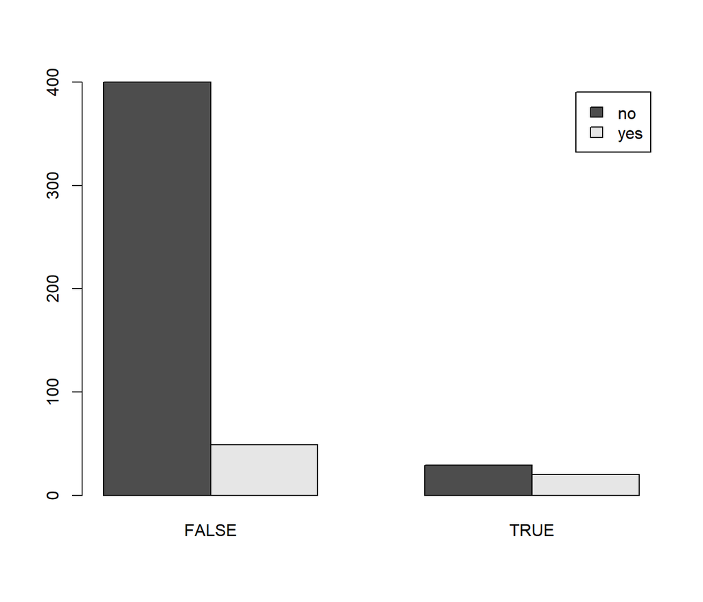

```r
swd=read.csv("SWDEFECTS.csv")
#PRED_LOC
tabLOC=with(swd, table(predict.loc.50,defect))
barplot(tabLOC,beside = TRUE, leg =TRUE)
```

```r
tabLOC=addmargins(tabLOC)
tabLOC
```

```
##               defect
## predict.loc.50 FALSE TRUE Sum
##            no    400   29 429
##            yes    49   20  69
##            Sum   449   49 498
```

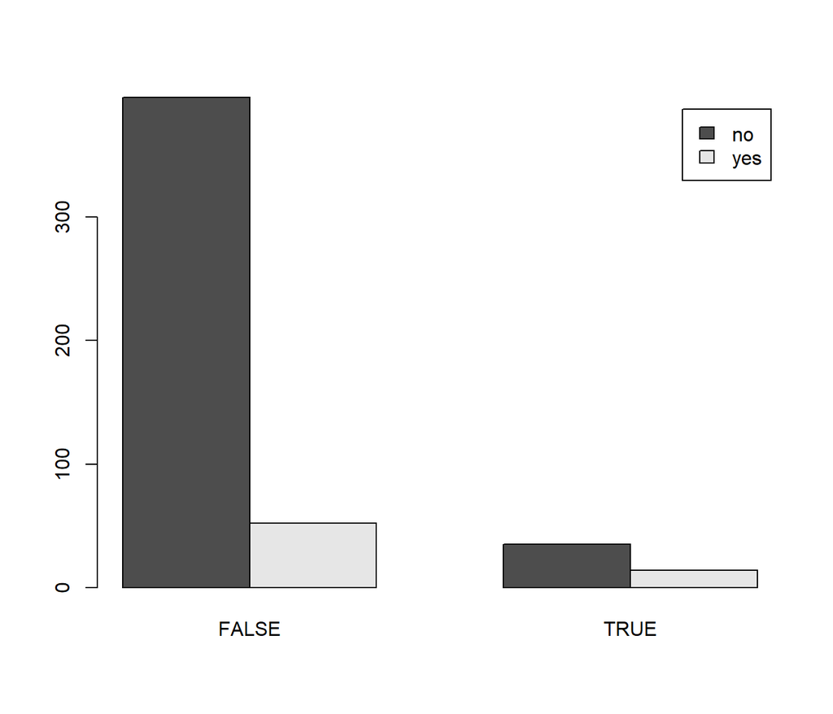

```r
#PRED_VG
tabVG=with(swd, table(predict.vg.10,defect))
barplot(tabVG,beside = TRUE, leg =TRUE)
```

```r
tabVG=addmargins(tabVG)
tabVG
```

```
##              defect
## predict.vg.10 FALSE TRUE Sum
##           no    397   35 432
##           yes    52   14  66
##           Sum   449   49 498
```

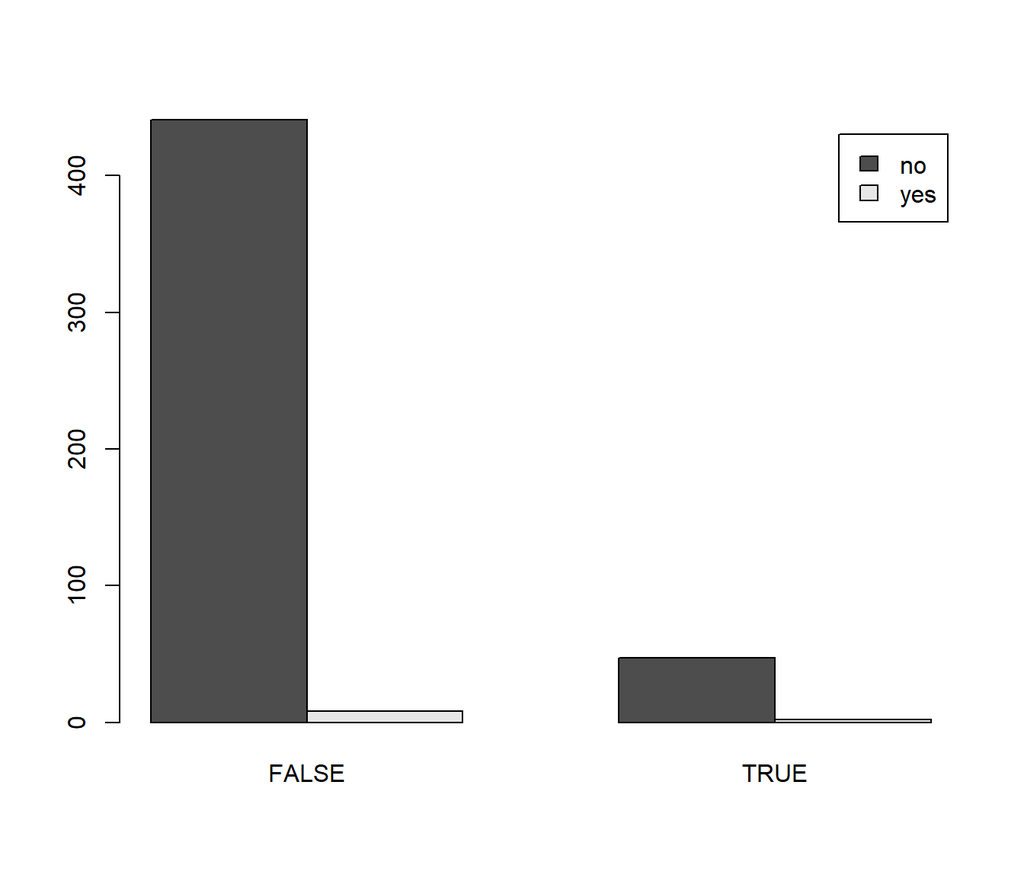

```r
#PRED_EVG
tabEVG=with(swd, table(predict.evg.14.5,defect))
barplot(tabEVG,beside = TRUE, leg =TRUE)
```

```r
tabEVG=addmargins(tabEVG)
tabEVG
```

```
##                 defect
## predict.evg.14.5 FALSE TRUE Sum
##              no    441   47 488
##              yes     8    2  10
##              Sum   449   49 498
```

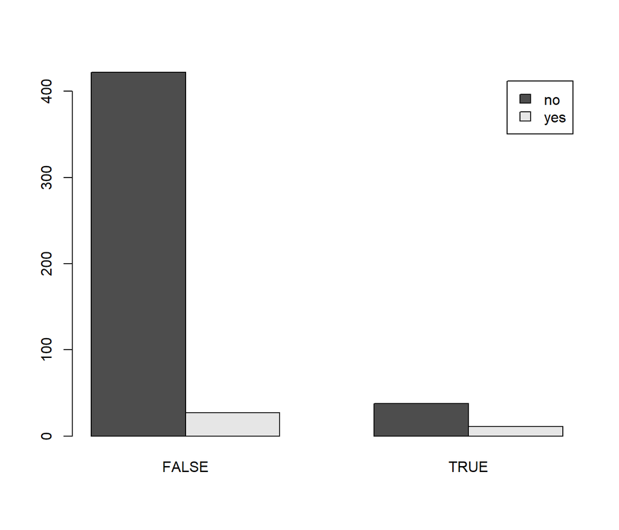

```r
#PRED_IVG
tabIVG=with(swd, table(predict.ivg.9.2,defect))
barplot(tabIVG,beside = TRUE, leg =TRUE)
```

```r
tabIVG=addmargins(tabIVG)
tabIVG
```

```
##                defect
## predict.ivg.9.2 FALSE TRUE Sum
##             no    422   38 460
##             yes    27   11  38
##             Sum   449   49 498
```

# 5 Create the corrected table on page 127

```r
#LOC row
a=tabLOC[1,1]
b=tabLOC[1,2]
c=tabLOC[2,1]
d=tabLOC[2,2]
LOCacc=acc(a,b,c,d)
LOCdetect=detect(b,d)
LOCfalarm=falarm(a,c)
LOCprec=prec(c,d)
#VG row
a=tabVG[1,1]
b=tabVG[1,2]
c=tabVG[2,1]
d=tabVG[2,2]
VGacc=acc(a,b,c,d)
VGdetect=detect(b,d)
VGfalarm=falarm(a,c)
VGprec=prec(c,d)
#EVG row
a=tabEVG[1,1]
b=tabEVG[1,2]
c=tabEVG[2,1]
d=tabEVG[2,2]
EVGacc=acc(a,b,c,d)
EVGdetect=detect(b,d)
EVGfalarm=falarm(a,c)
EVGprec=prec(c,d)
#IVG row
a=tabIVG[1,1]
b=tabIVG[1,2]
c=tabIVG[2,1]
d=tabIVG[2,2]
IVGacc=acc(a,b,c,d)
IVGdetect=detect(b,d)
IVGfalarm=falarm(a,c)
IVGprec=prec(c,d)

tab3<-matrix(c(LOCacc,LOCdetect,LOCfalarm,LOCprec,
               VGacc,VGdetect,VGfalarm,VGprec,
               EVGacc,EVGdetect,EVGfalarm,EVGprec,
               IVGacc,IVGdetect,IVGfalarm,IVGprec),
               ncol=4,byrow=TRUE)
colnames(tab3)=c("Accuracy","Dectection Rate","False Alarm Rate","Precision")
rownames(tab3)=c("Line of code","Cyclomatic complexity","Essential Complexity","Design Complexity")
tab3 = as.table(tab3)
tab3
```

```
##                       Accuracy Dectection Rate False Alarm Rate Precision
## Line of code             0.843           0.408            0.109     0.290
## Cyclomatic complexity    0.825           0.286            0.116     0.212
## Essential Complexity     0.890           0.041            0.018     0.200
## Design Complexity        0.869           0.224            0.060     0.289
```

# 6 mybar() function

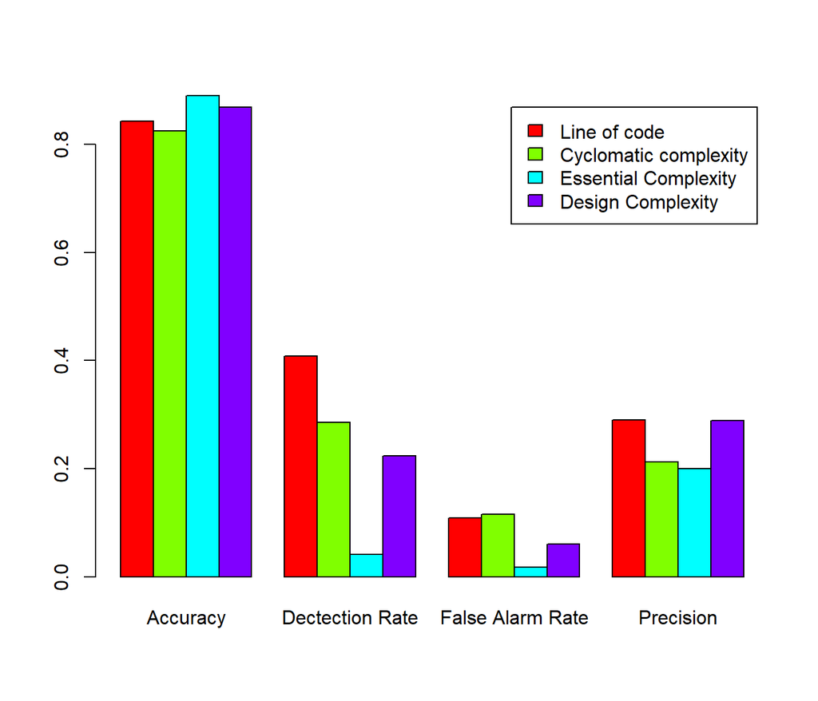

```r
mybar=function(tab,acc){
  barplot(tab,beside=TRUE,col=rainbow(4),legend = rownames(tab))
}
mybar(tab3)
```